# Red Wine Quality: Exploration Data Analysis

### by Shaswati Ghosh

Below analysis is done to find the relation between ‘Quality’ of red wine and other parameters. The data set is containing 1,599 red wines with 11 chemical properties of the wine. The quality rating is between 0 (very bad) and 10 (very excellent).

## Data Set Analysis

##### Dimension of data set

```
## [1] 1599   13
```

##### Name of columns

```
##  [1] "X"                    "fixed.acidity"        "volatile.acidity"
##  [4] "citric.acid"          "residual.sugar"       "chlorides"
##  [7] "free.sulfur.dioxide"  "total.sulfur.dioxide" "density"
## [10] "pH"                   "sulphates"            "alcohol"
## [13] "quality"
```

##### Structure of dataset

```
## 'data.frame':    1599 obs. of  13 variables:
##  $ X                   : int  1 2 3 4 5 6 7 8 9 10 ...
##  $ fixed.acidity       : num  7.4 7.8 7.8 11.2 7.4 7.4 7.9 7.3 7.8 7.5 ...
##  $ volatile.acidity    : num  0.7 0.88 0.76 0.28 0.7 0.66 0.6 0.65 0.58 0.5 ...
##  $ citric.acid         : num  0 0 0.04 0.56 0 0 0.06 0 0.02 0.36 ...
##  $ residual.sugar      : num  1.9 2.6 2.3 1.9 1.9 1.8 1.6 1.2 2 6.1 ...
##  $ chlorides           : num  0.076 0.098 0.092 0.075 0.076 0.075 0.069 0.065 0.073 0.071 ...
##  $ free.sulfur.dioxide : num  11 25 15 17 11 13 15 15 9 17 ...
##  $ total.sulfur.dioxide: num  34 67 54 60 34 40 59 21 18 102 ...
##  $ density             : num  0.998 0.997 0.997 0.998 0.998 ...
##  $ pH                  : num  3.51 3.2 3.26 3.16 3.51 3.51 3.3 3.39 3.36 3.35 ...
##  $ sulphates           : num  0.56 0.68 0.65 0.58 0.56 0.56 0.46 0.47 0.57 0.8 ...
##  $ alcohol             : num  9.4 9.8 9.8 9.8 9.4 9.4 9.4 10 9.5 10.5 ...
##  $ quality             : int  5 5 5 6 5 5 5 7 7 5 ...
```

All the variables are either integer or numeric. Our main goal is to find the effect of other parameters determining the wine QUALITY. And QUALITY is numeric int type. If we convert this to a factor, the analysis would be easier. Hence adding a new variable in the data frame as ‘quality.factor’.

##### Adding new parameters

```
##   X fixed.acidity volatile.acidity citric.acid residual.sugar chlorides
## 1 1           7.4             0.70        0.00            1.9     0.076
## 2 2           7.8             0.88        0.00            2.6     0.098
## 3 3           7.8             0.76        0.04            2.3     0.092
## 4 4          11.2             0.28        0.56            1.9     0.075
## 5 5           7.4             0.70        0.00            1.9     0.076
## 6 6           7.4             0.66        0.00            1.8     0.075
##   free.sulfur.dioxide total.sulfur.dioxide density   pH sulphates alcohol
## 1                  11                   34  0.9978 3.51      0.56     9.4
## 2                  25                   67  0.9968 3.20      0.68     9.8
## 3                  15                   54  0.9970 3.26      0.65     9.8
## 4                  17                   60  0.9980 3.16      0.58     9.8
## 5                  11                   34  0.9978 3.51      0.56     9.4
## 6                  13                   40  0.9978 3.51      0.56     9.4
##   quality quality.factor
## 1       5              5
## 2       5              5
## 3       5              5
## 4       6              6
## 5       5              5
## 6       5              5
```

## Univariate Plots and Analysis

Let’s find the summary of all the variables.

```
##        X          fixed.acidity   volatile.acidity  citric.acid
##  Min.   :   1.0   Min.   : 4.60   Min.   :0.1200   Min.   :0.000
##  1st Qu.: 400.5   1st Qu.: 7.10   1st Qu.:0.3900   1st Qu.:0.090
##  Median : 800.0   Median : 7.90   Median :0.5200   Median :0.260
##  Mean   : 800.0   Mean   : 8.32   Mean   :0.5278   Mean   :0.271
##  3rd Qu.:1199.5   3rd Qu.: 9.20   3rd Qu.:0.6400   3rd Qu.:0.420
##  Max.   :1599.0   Max.   :15.90   Max.   :1.5800   Max.   :1.000
##  residual.sugar     chlorides       free.sulfur.dioxide
##  Min.   : 0.900   Min.   :0.01200   Min.   : 1.00
##  1st Qu.: 1.900   1st Qu.:0.07000   1st Qu.: 7.00
##  Median : 2.200   Median :0.07900   Median :14.00
##  Mean   : 2.539   Mean   :0.08747   Mean   :15.87
##  3rd Qu.: 2.600   3rd Qu.:0.09000   3rd Qu.:21.00
##  Max.   :15.500   Max.   :0.61100   Max.   :72.00
##  total.sulfur.dioxide    density             pH          sulphates
##  Min.   :  6.00       Min.   :0.9901   Min.   :2.740   Min.   :0.3300
##  1st Qu.: 22.00       1st Qu.:0.9956   1st Qu.:3.210   1st Qu.:0.5500
##  Median : 38.00       Median :0.9968   Median :3.310   Median :0.6200
##  Mean   : 46.47       Mean   :0.9967   Mean   :3.311   Mean   :0.6581
##  3rd Qu.: 62.00       3rd Qu.:0.9978   3rd Qu.:3.400   3rd Qu.:0.7300
##  Max.   :289.00       Max.   :1.0037   Max.   :4.010   Max.   :2.0000
##     alcohol         quality      quality.factor
##  Min.   : 8.40   Min.   :3.000   3: 10
##  1st Qu.: 9.50   1st Qu.:5.000   4: 53
##  Median :10.20   Median :6.000   5:681
##  Mean   :10.42   Mean   :5.636   6:638
##  3rd Qu.:11.10   3rd Qu.:6.000   7:199
##  Max.   :14.90   Max.   :8.000   8: 18
```

##### Distribution of each parameter separately

Goal of this analysis is to find the dependency of QUALITY on other variables. Let’s see the table for QUALITY.

```
##
##   3   4   5   6   7   8
##  10  53 681 638 199  18
```

Next we will check distribution of each parameter to get some initial idea about them.

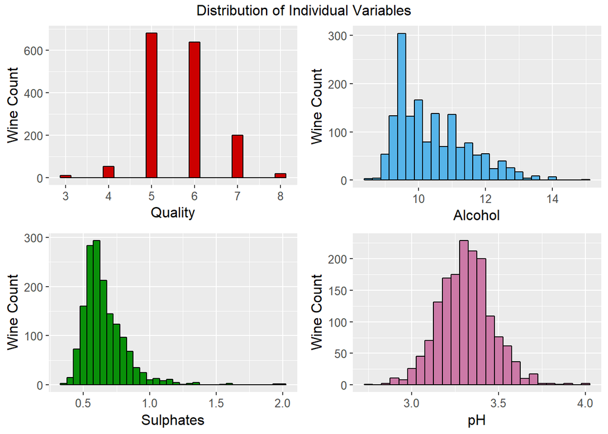

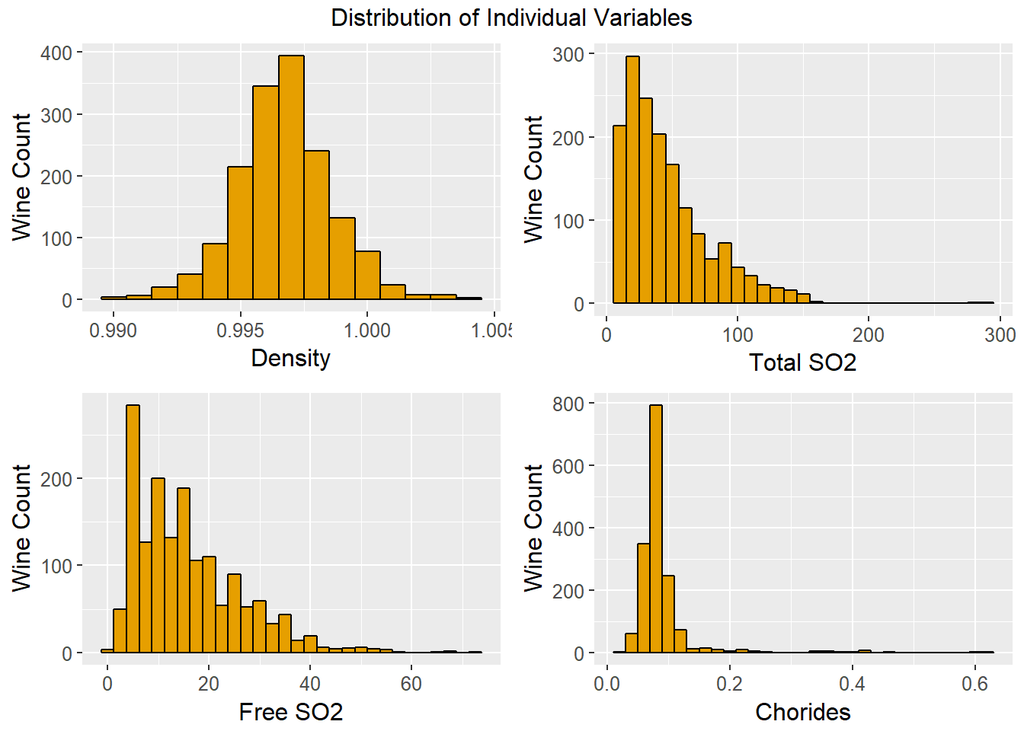

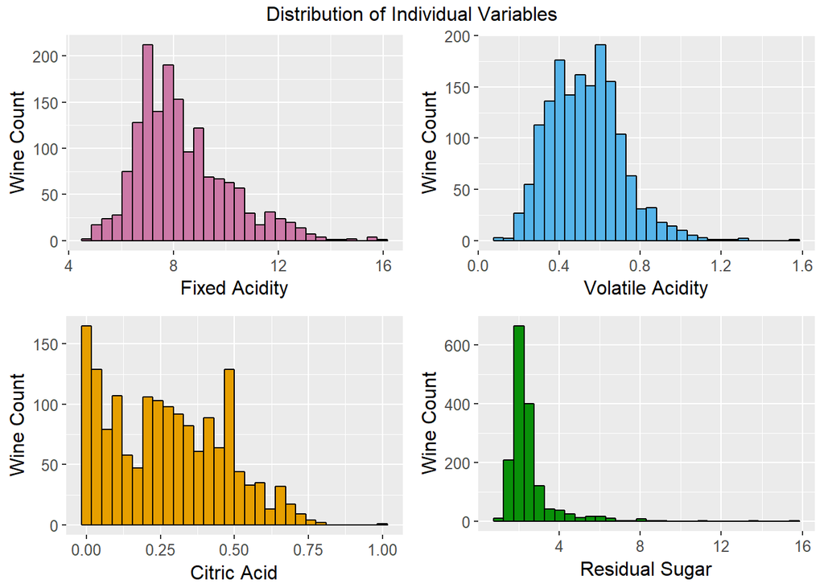

Citric acid has peak at 0 value. Let’s find which wine quality has highest contribution in that peak. Group of wine having citric acid as 0.

```
## csubset$citric.acid: 0
##  3  4  5  6  7  8
##  3 10 57 54  8  0
```

Distribution of SULPHATES, TOTAL.SULFUR.DIOXIDE, FREE.SULFUR.DIOXIDE, CHLORIDES, and RESIDUAL.SUGAR are right skewed. Hopefully transforming them to log10 can give a better visualization.

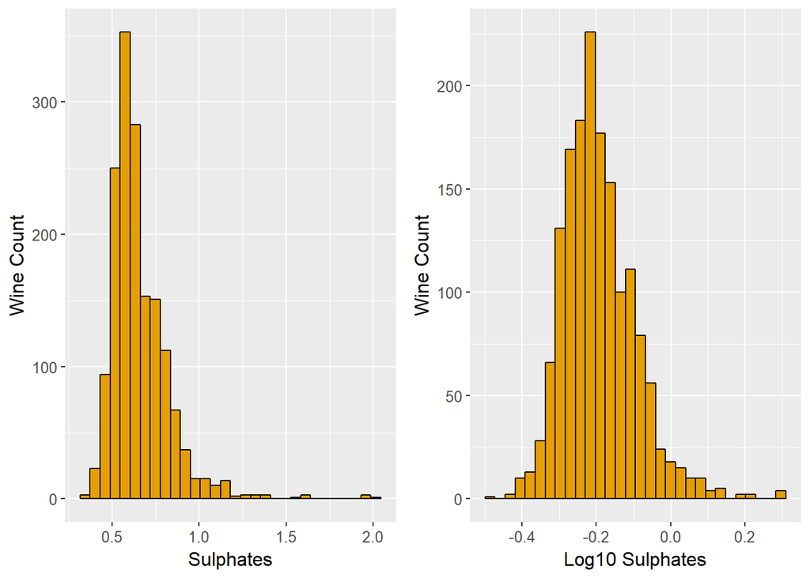

So here we have a better distribution. Other distribution with Log10.

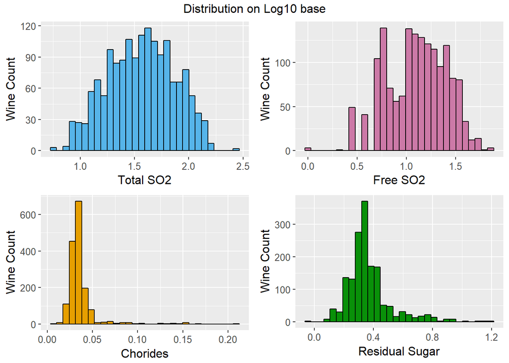

Now we have a much better distribution visualization for those variables.

A new variable has been added ‘quality.factor’ for better analysis. Initial analysis has shown that if we further categories wine quality, we can have a more clear view. Creating another variable in the data set called ‘quality.cat’. According to table distribution of ‘quality’, creating 3 categories. ‘<= 4’ : Low ‘5,6’ : Medium ‘>= 7’ : High

```
##   X fixed.acidity volatile.acidity citric.acid residual.sugar chlorides
## 1 1           7.4             0.70        0.00            1.9     0.076
## 2 2           7.8             0.88        0.00            2.6     0.098
## 3 3           7.8             0.76        0.04            2.3     0.092
## 4 4          11.2             0.28        0.56            1.9     0.075
## 5 5           7.4             0.70        0.00            1.9     0.076
##   free.sulfur.dioxide total.sulfur.dioxide density   pH sulphates alcohol
## 1                  11                   34  0.9978 3.51      0.56     9.4
## 2                  25                   67  0.9968 3.20      0.68     9.8
## 3                  15                   54  0.9970 3.26      0.65     9.8
## 4                  17                   60  0.9980 3.16      0.58     9.8
## 5                  11                   34  0.9978 3.51      0.56     9.4
##   quality quality.factor quality.cat
## 1       5              5      Medium
## 2       5              5      Medium
## 3       5              5      Medium
## 4       6              6      Medium
## 5       5              5      Medium
```

```
## csubset$citric.acid: 0
##    Low Medium   High
##     13    111      8
```

Let’s have distribution of these two new variables and compare the same with ‘quality’.

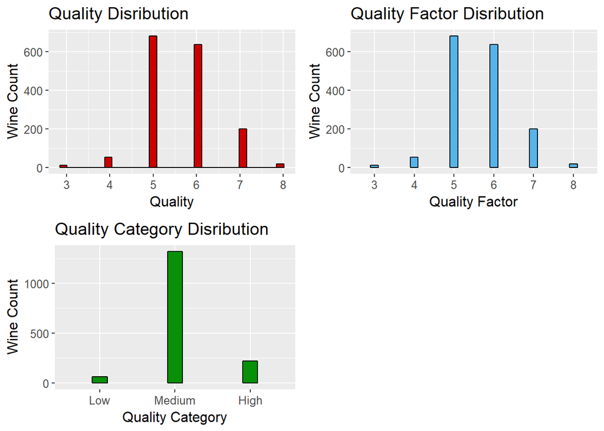

As expected, both the variables ‘quality’ and ‘quality.factor’ have same distribution. Distribution of’quality.cat’ more clearly shows the difference of medium range wine and the combination of other two quality ranges wine.

## Bivariate Plots and Analysis

Let’s find out the pearson correlation matrix for all the variables. This table gives an initial idea about the dependency of variables on each other.

##### Correlation Table

1st column has no name , but we will need to remove the column to have a proper set of data to prepare the correlation table. Hence renaming the 1st column.

```
##  [1] "1stCol"               "fixed.acidity"        "volatile.acidity"
##  [4] "citric.acid"          "residual.sugar"       "chlorides"
##  [7] "free.sulfur.dioxide"  "total.sulfur.dioxide" "density"
## [10] "pH"                   "sulphates"            "alcohol"
## [13] "quality"              "quality.factor"       "quality.cat"
```

Creating the subset to remove unwanted columns before populating the Correlation Factor. Few column heading is too big, which may be cut in the correlation plot, so renaming those to a shorter form as well.

```
##   fixed.acidity volatile.acidity citric.acid residual.sugar chlorides
## 1           7.4             0.70        0.00            1.9     0.076
## 2           7.8             0.88        0.00            2.6     0.098
## 3           7.8             0.76        0.04            2.3     0.092
## 4          11.2             0.28        0.56            1.9     0.075
## 5           7.4             0.70        0.00            1.9     0.076
## 6           7.4             0.66        0.00            1.8     0.075
##   free SO2 total SO2 density   pH sulphates alcohol quality
## 1       11        34  0.9978 3.51      0.56     9.4       5
## 2       25        67  0.9968 3.20      0.68     9.8       5
## 3       15        54  0.9970 3.26      0.65     9.8       5
## 4       17        60  0.9980 3.16      0.58     9.8       6
## 5       11        34  0.9978 3.51      0.56     9.4       5
## 6       13        40  0.9978 3.51      0.56     9.4       5
```

The Correlation Table

```
##                  fixed.acidity volatile.acidity citric.acid residual.sugar
## fixed.acidity          1.00000         -0.25613     0.67170        0.11478
## volatile.acidity      -0.25613          1.00000    -0.55250        0.00192
## citric.acid            0.67170         -0.55250     1.00000        0.14358
## residual.sugar         0.11478          0.00192     0.14358        1.00000
## chlorides              0.09371          0.06130     0.20382        0.05561
## free SO2              -0.15379         -0.01050    -0.06098        0.18705
## total SO2             -0.11318          0.07647     0.03553        0.20303
## density                0.66805          0.02203     0.36495        0.35528
## pH                    -0.68298          0.23494    -0.54190       -0.08565
## sulphates              0.18301         -0.26099     0.31277        0.00553
## alcohol               -0.06167         -0.20229     0.10990        0.04208
## quality                0.12405         -0.39056     0.22637        0.01373
##                  chlorides free SO2 total SO2  density       pH sulphates
## fixed.acidity      0.09371 -0.15379  -0.11318  0.66805 -0.68298   0.18301
## volatile.acidity   0.06130 -0.01050   0.07647  0.02203  0.23494  -0.26099
## citric.acid        0.20382 -0.06098   0.03553  0.36495 -0.54190   0.31277
## residual.sugar     0.05561  0.18705   0.20303  0.35528 -0.08565   0.00553
## chlorides          1.00000  0.00556   0.04740  0.20063 -0.26503   0.37126
## free SO2           0.00556  1.00000   0.66767 -0.02195  0.07038   0.05166
## total SO2          0.04740  0.66767   1.00000  0.07127 -0.06649   0.04295
## density            0.20063 -0.02195   0.07127  1.00000 -0.34170   0.14851
## pH                -0.26503  0.07038  -0.06649 -0.34170  1.00000  -0.19665
## sulphates          0.37126  0.05166   0.04295  0.14851 -0.19665   1.00000
## alcohol           -0.22114 -0.06941  -0.20565 -0.49618  0.20563   0.09359
## quality           -0.12891 -0.05066  -0.18510 -0.17492 -0.05773   0.25140
##                   alcohol  quality
## fixed.acidity    -0.06167  0.12405
## volatile.acidity -0.20229 -0.39056
## citric.acid       0.10990  0.22637
## residual.sugar    0.04208  0.01373
## chlorides        -0.22114 -0.12891
## free SO2         -0.06941 -0.05066
## total SO2        -0.20565 -0.18510
## density          -0.49618 -0.17492
## pH                0.20563 -0.05773
## sulphates         0.09359  0.25140
## alcohol           1.00000  0.47617
## quality           0.47617  1.00000
```

To get the correlation matrix, we need a proper subset of columns. The first column does not have any name, hence first assigning a name to it and then creating a subset removing first and last column(this is newly added factor for quality value). Then populating the correlation table.

#### Correlation Matrix plot

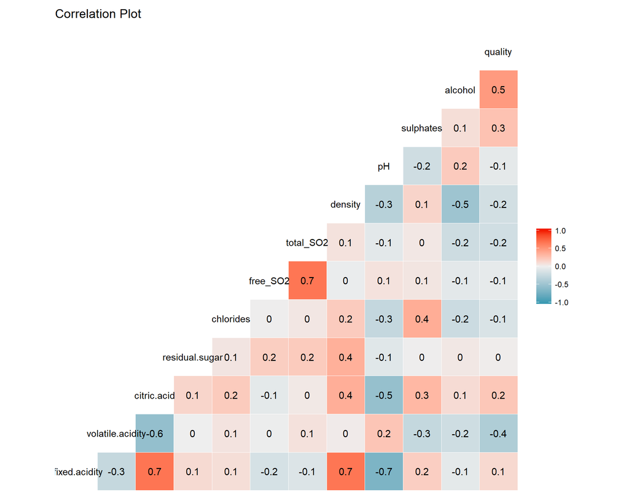

##### Box Plots

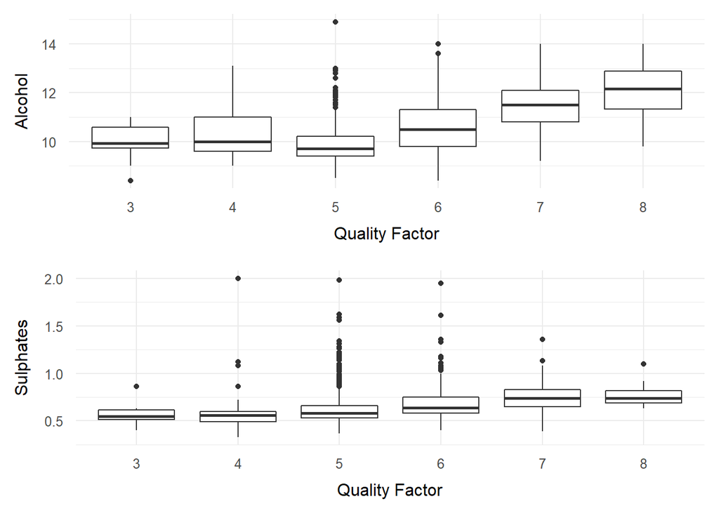

Boxplot distribution supports the fact that, higher quality wine has high ALCOHOL percentage and high SULPHATES amount. To get a better view of SULPHATES one, limiting the Y-axis.

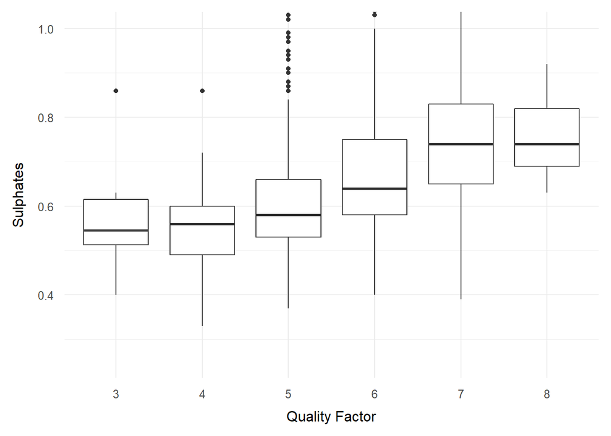

This shows the increase of SULPHATES with better quality. Other plots are as below.

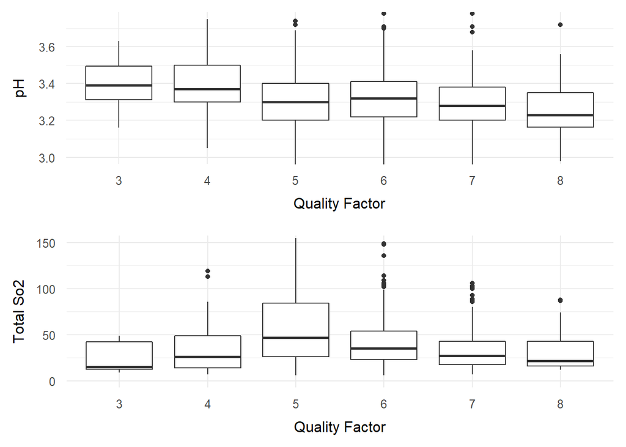

pH has decreasing value with increase in QUALITY. Here we can see some interesting distribution for TOTAL.SULFUR.DIOXIDE. Amount of ‘Total So2’ is higher for wine quality of 5 and 6, Where as the same is less for both the lower and higher quality than the middle one.

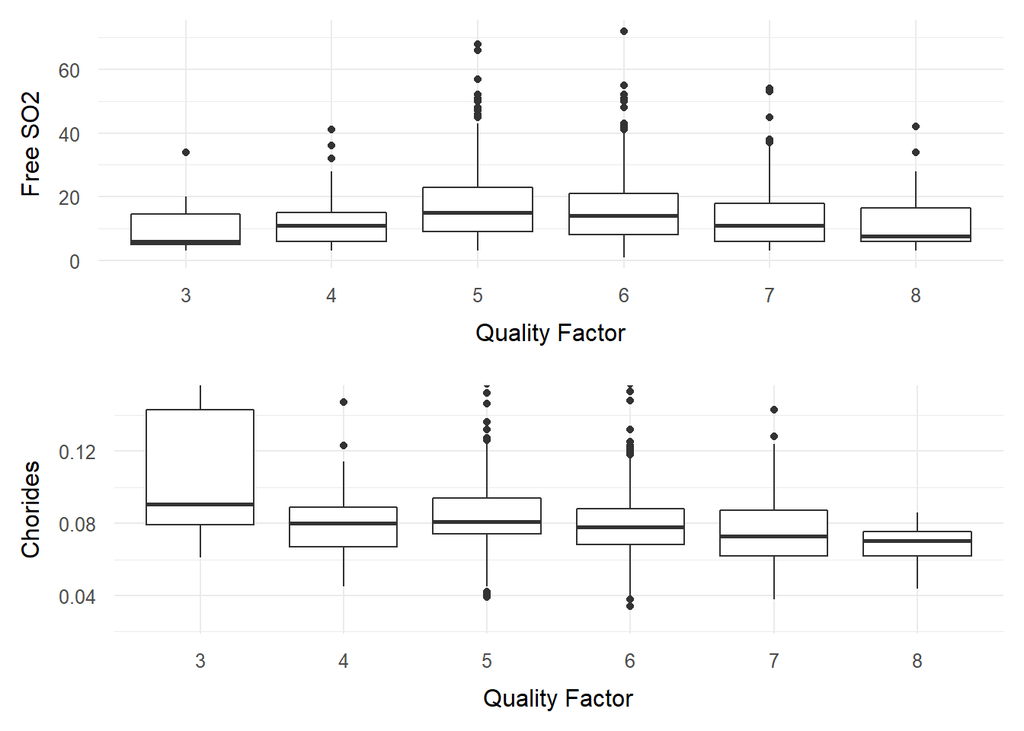

Free SO2 is also having almost same distribution as ‘Total SO2’. As the quality moves to both the extreme end, i.e. to either very low or very high, ‘Free SO2’ has decreased value compared to medium quality(4,5,6,7) wine.

Chlorides has decreasing amount as the wine quality increases. For quality 8, most of them are below mean value.

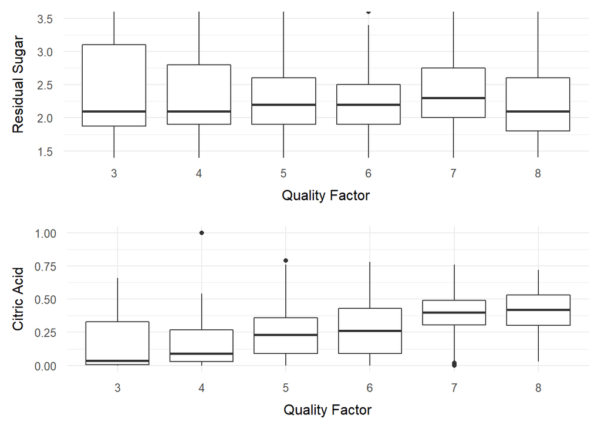

Y axis has been cut down to get a better and closure view for RESIDUAL.SUGAR. We can see that his variable has no specific effect on wine quality. But for CITRIC.ACID has a very prominant influence on wine QUALITY. Increase in wine quality shows good amount of increase in ‘Citric Acid’.

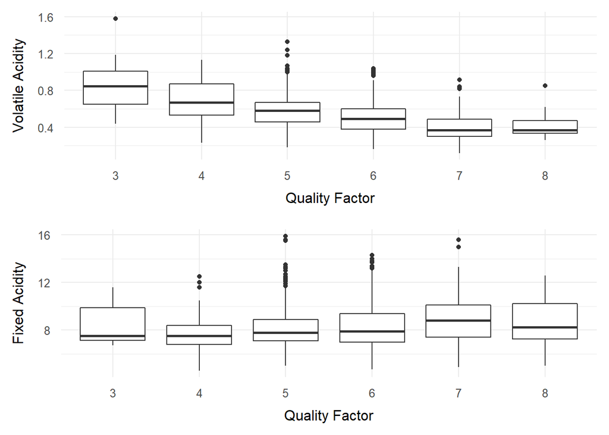

VOLATILE.ACIDITY has decreasing value with increase in wine quality and the relation is strong enough. FIXED.ACIDITY does not show any specific effect on wine QUALITY at this plot.

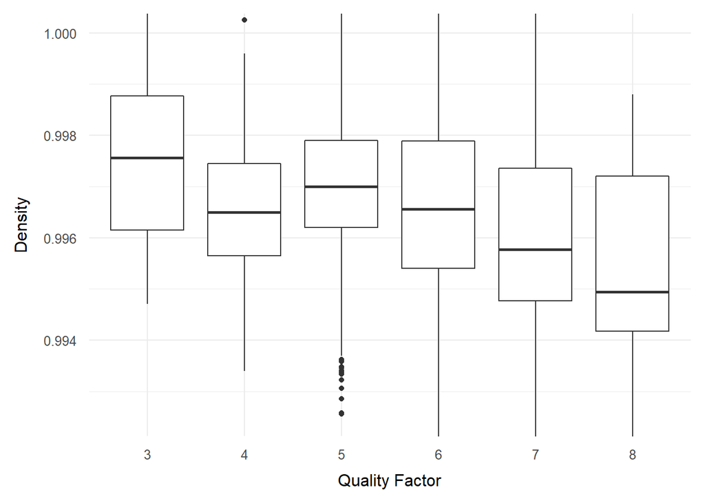

Higher quality wine has little less DENSITY.

After analysing the above plots, we can say that some of them are having positove relationship and some of them are having negative relationship with quality. ‘Alcohol’, ‘Citric Acid’ shows some strong increasing relation with quality. ‘Sulphates’. ‘Fixed Acidity’ also shows increasing value with better quality, but not too prominent. ‘pH’. ‘Chlorides’,‘Volatile Acidity’, ‘Density’ have decreasing value with increasing quality. ‘Total SO2’, ‘Free SO2’ have higher value for middle range and lower balue for both low and high quality wine. ‘Residual Sugar’ is not showing any significant effect on quality determination.

These plots shows that, if we further categories wine quality, we can have a more clear view. Now we will see the distribution against QUALITY.CAT

Preparing a scatter plot of ‘Quality.Cat vs Alcohol’ and ‘Quality.Cat vs Volatile Acidity’ to see wine’s count variation along both the variables.

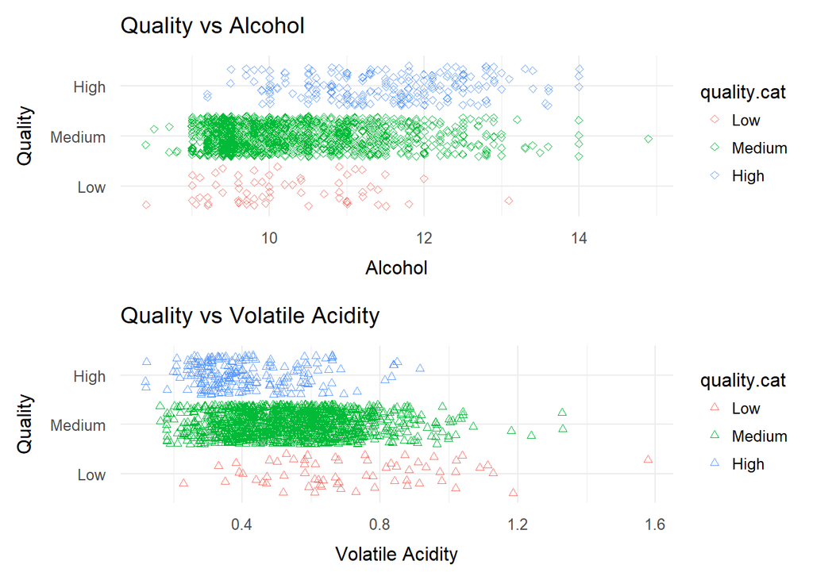

This plot describes the relation of ‘Alcohol’ and ‘Volatile Acidity’ with newly derived quality category.

Now let’s find the relation of other variables with this new variable quality category.

##### Increasing Relation

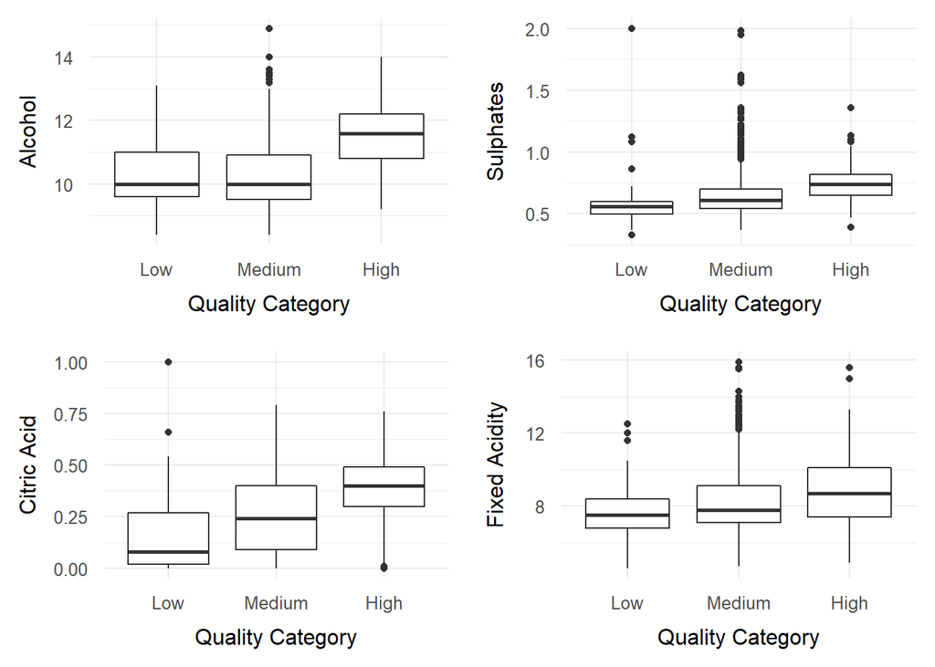

#### Decreasing Relation

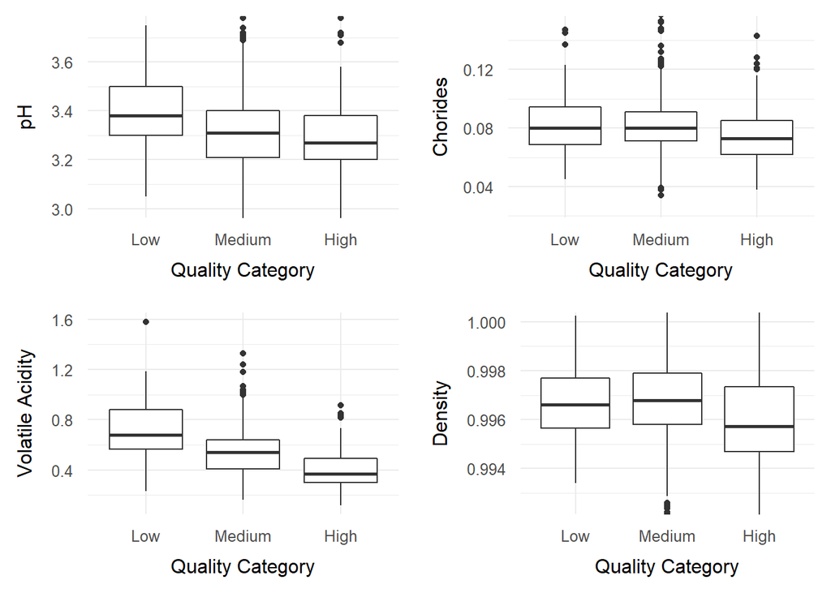

#### Other variables box plot

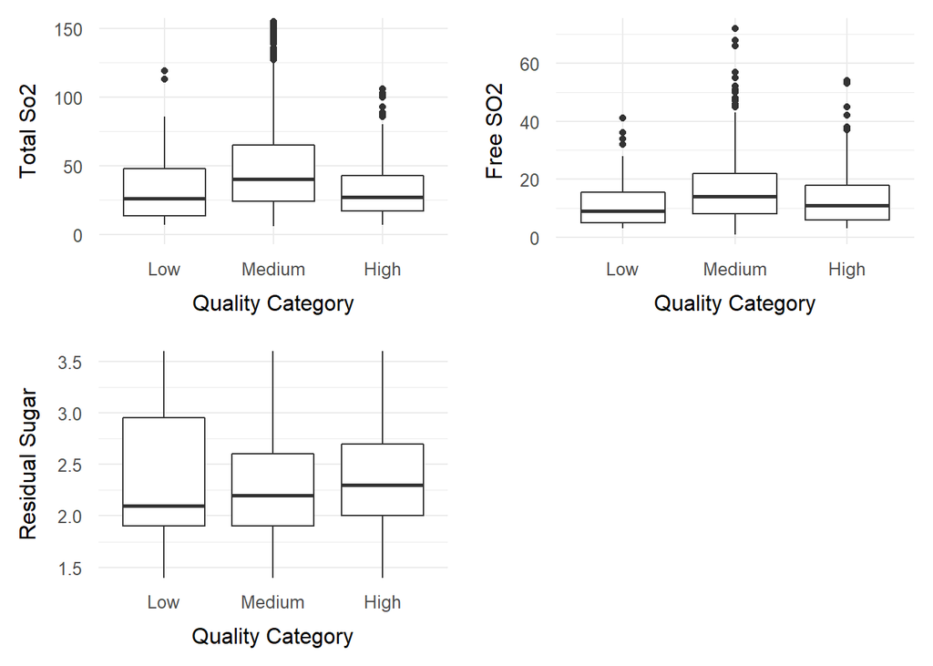

Behaviour of ‘Total SO2’ and ‘Free SO2’ shows the same pattern here as well. But ‘Residual.Sugar’ shows slight increasing relation with this QUALITY.CAT which was not that much clear in previous plots.

The correlation table shows some good relationship between below pair of variables. Density & Fixed.Acidtity Density & Residual Sugar pH & Fixed Acidity ph & Citric.Acid Sulphates & Chlorides Alcohol & Density

Let’s have a quick plot for them.

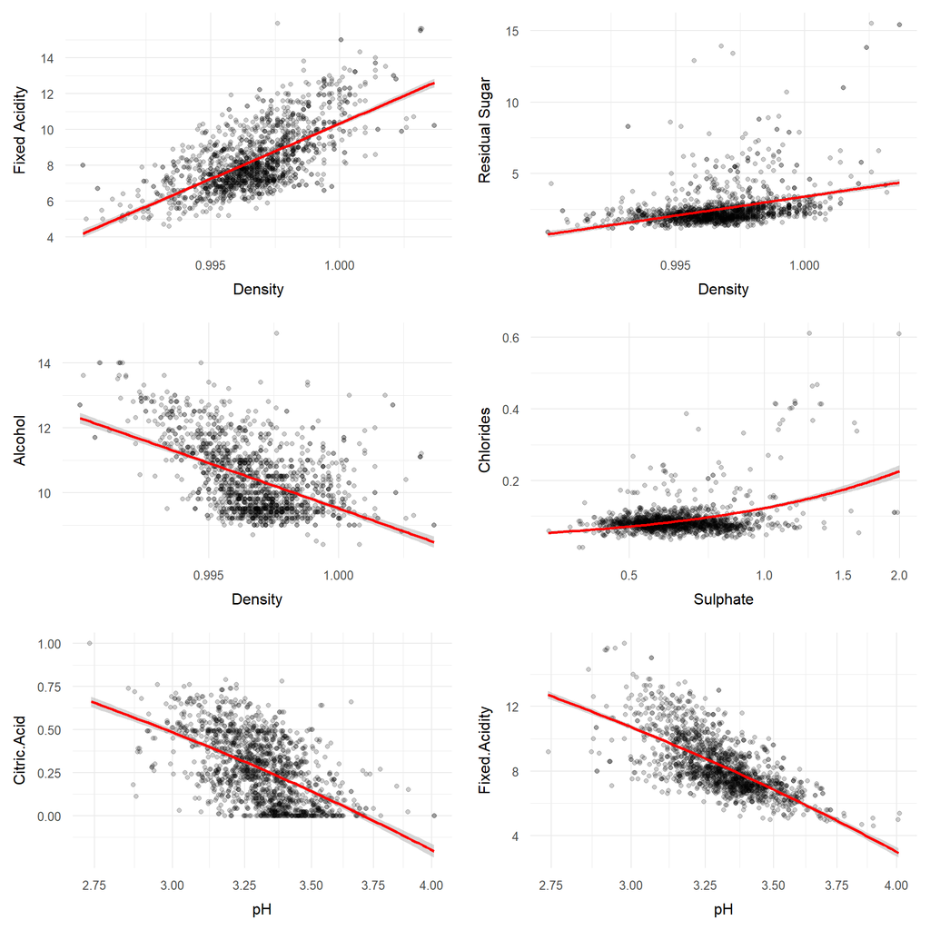

### Analysis of Biivariate plots

Alcohol, Sulphates, Citric Acid and Fixed Acidity have shown increasing relation with higher quality. Where as pH, Chlorides, Volatile Acidity and Density have shown decreasing relation with higher quality. Alcohol and Volatile acidity have stronger relationship with ‘Quality’ compared to any other variables. Stongest relationship among all the variable is found between ‘pH’ and ‘Fixed.Acidity’ and ‘Free SO2’ and ‘Total So2’. ‘Free SO2’ and ‘Total SO2’ has some interesting relationship with ‘Quality’. For medium quality(5,6) their value is higher compared to both low(3,4) and high(7,8) quality category.

## Multi Variate Plots and Analysis

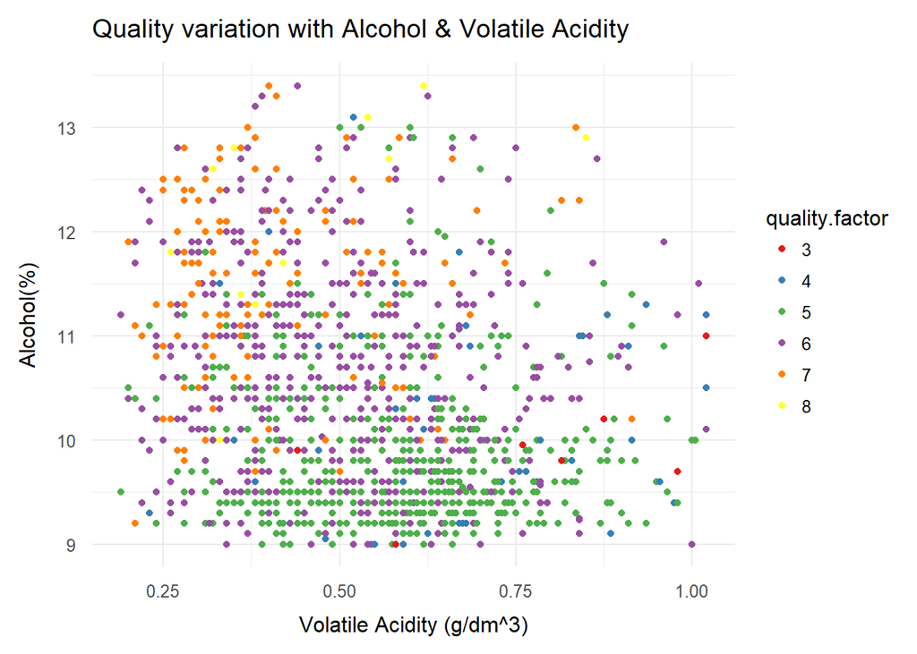

To get the better separation,plotting against quality category.

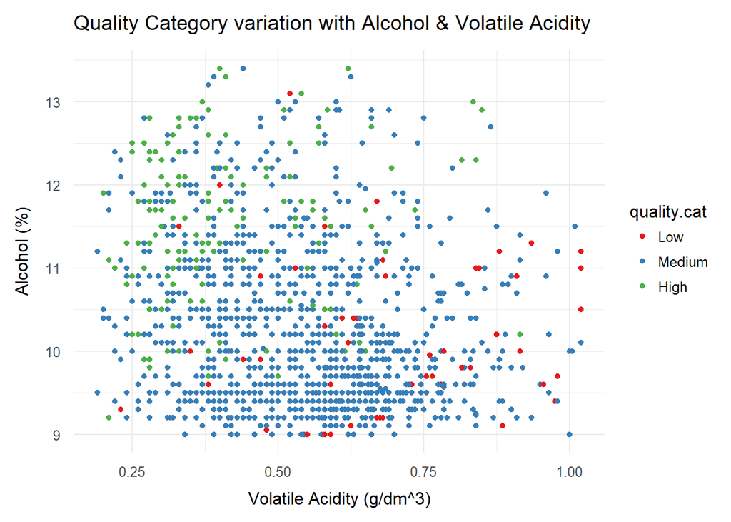

Green dots are mainly found on the upper left side, but the blue one is spreaded almost all over the area. Red dots are also not concentrated in any specific area. So it can be said that, higher quality wine is having high ‘alcohol’ and low ‘volatile acidity’, but medium and lower range are almost spreaded all over the plotted area with little higher density in lower ‘alcohol’ percentage.This specifically supports the outcoe of correlation matrix which shows the correlation coefficient of ‘alcohol’ and ‘quality’ is higher compared to the same of volatile acidity and quality.

Let’s see the scatter plot of ‘Quality.cat’ with variation of ‘volatile acidity’ and ‘pH’. ’’

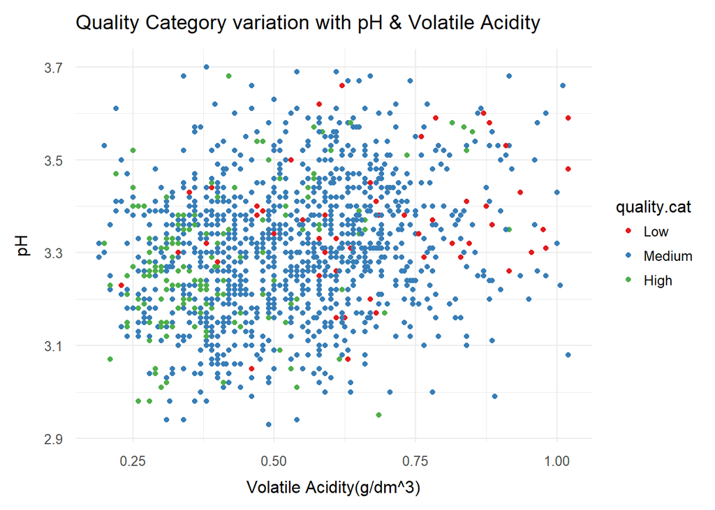

Most of the higher quality wines are spotted on the left side of the plot, which indicates the lower value of ‘volatile.acidity’ and those spots show some concentrated value near pH = 3.3. Still this plot does not speak about any specific relation.

Previous boxplots have shown that increase in sulphates and alcohol causes an increase in quality. Let’s check how does it look in a scatterplot.

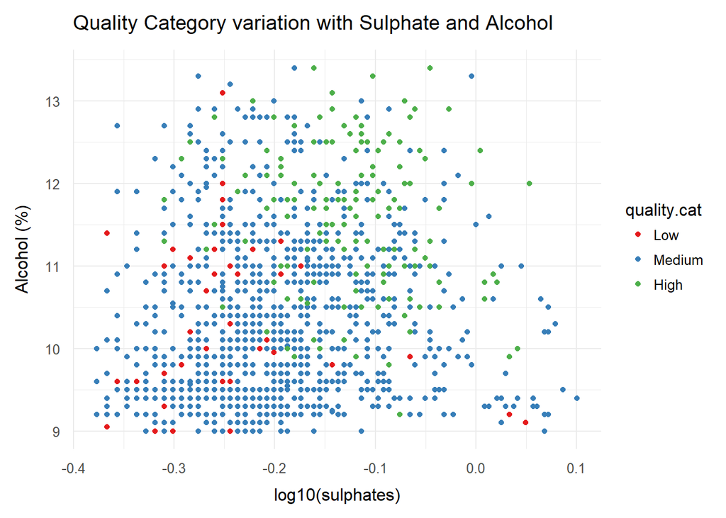

In the plot, green dots(high category wines) found on the upper right side, where combination of both the variables are high.

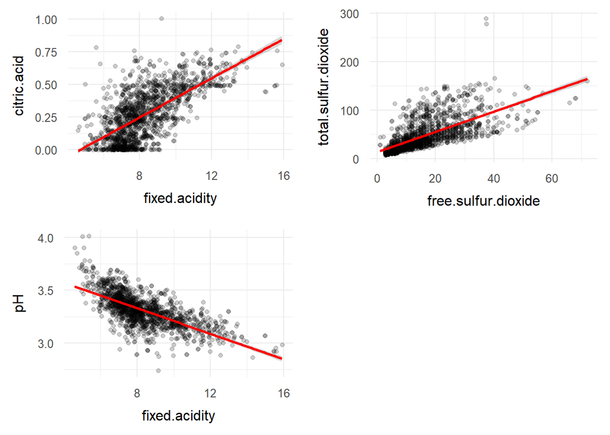

## Final Plots

##### Plot 1: Alcohol and Volatile Acidity with Quality

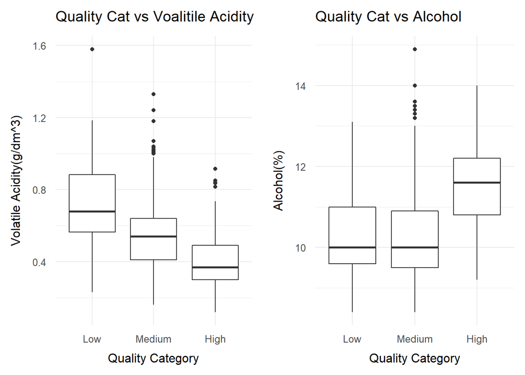

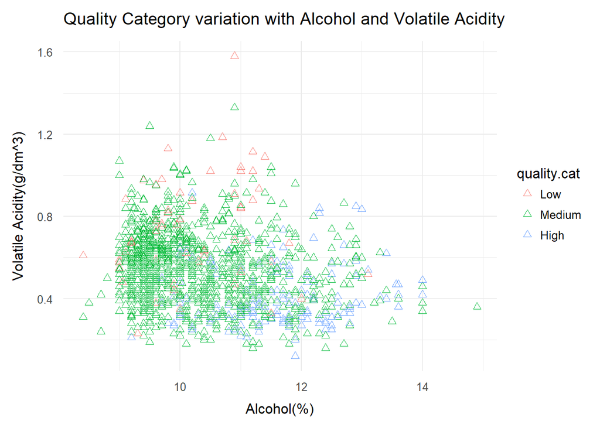

##### Plot 2: Free SO2 and Total SO2 with Quality

The amount of ‘free sulfur dioxide’ and ‘total sulfur dioxide’ vary greatly for the given sample data, from 1 to 72 for ‘free SO2’ and from 6 to 289 for ‘total SO2’. These are huge range. Use of SO2 in wine is a concern for health related issues.

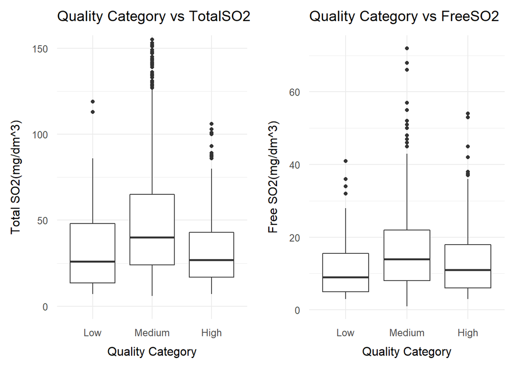

Correlation table shows that ‘free SO2’ and ‘total SO2’ both have very low negative correlation coeffeciant with wine ‘quality’. Above box plots shows some interesting influence on wine quality. Their value is higher for medium category(5,6) and lower for both the other two category. They do not have any directional influence on wine quality, but their value is low for high quality wine.

##### Plot 3: Sulphate and Alcohol VS Quality

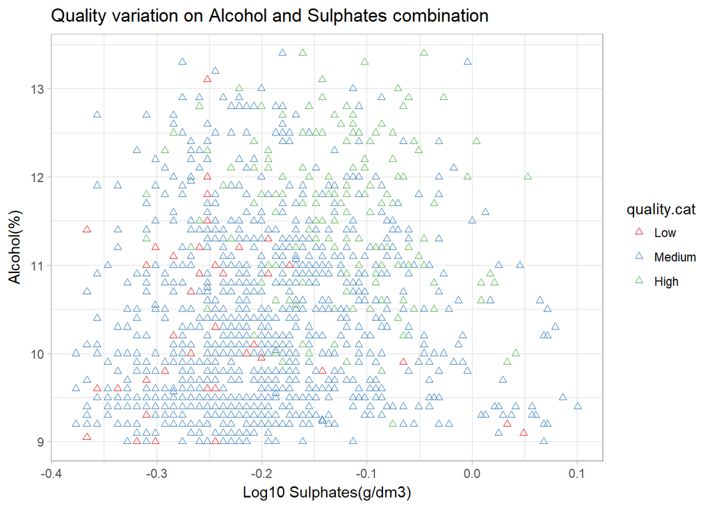

‘Sulphates’ has a positive correlation coefficient of 0.3 with wine quality. After ‘alcohol’ and ‘volatile acidity’, this is the next influential ingredient to determine the wine quality as per correlation table. Both ‘alcohol’ and ‘sulphates’ increasing value with increase in wine quality.  
Higher quality wine is on the upper right side, which denotes high value of both ‘Alcohol’ and ‘Sulphates’. Combination of these two variables are doing big part it determining the quality.